# s2_Index_Stocks Portfolio Summary Report

2025-07-11

*Summary report for the s2_Index_Stocks portfolio. The report is designed to provide an overview of the historical results for the strategy, including performance metrics, risk assessment, and visualizations.*

| Parameter | Value |
| --- | --- |
| date_range | 2024-05-28, 2025-07-11 |
| num_stocks | 508 |
| strategy | s2 |
| portfolio_size | 10 |

## 1. Portfolio Performance

### a) Performance Plot

**Returns are based on a portfolio size of 10.**

Interactive plot showing the cumulative return of the portfolio over time.

[interactive chart not shown]

*Simulated_Strategy is this portfolio’s performance; Composite_Tickers represents equal ownership of all stocks in the stock list; SPY is SPDR S&P 500 ETF Trust benchmark; QQQ is Invesco QQQ Trust, Series 1 representing the Nasdaq benchmark.*

### b) Trading Log

This table provides a log of all trades executed by the strategy.

|  | Ticker | Date | Close | buy_prob | sellDate | sellPrice | Trigger | return | days_held |
| --- | --- | --- | --- | --- | --- | --- | --- | --- | --- |
| 1 | AEE | 2024-06-03 | 70.9107642422098 | 0.7194394 | 2024-07-02 | 69.3852659411995 | gain_min | -0.02151292991004363 | 29 |
| 2 | ATO | 2024-06-03 | 112.85504257358 | 0.70723534 | 2024-07-05 | 111.98549891597 | gain_min | -0.007704960609474443 | 32 |
| 3 | NTRS | 2024-06-03 | 80.3978988202519 | 0.67712456 | 2024-07-10 | 82.8675738785772 | gain_min | 0.03071815426230028 | 37 |
| 4 | O | 2024-06-03 | 50.1924175311101 | 0.6714289 | 2024-06-27 | 49.3638801567455 | model_sell | -0.01650722190958543 | 24 |
| 5 | WRB | 2024-06-03 | 51.6864718799872 | 0.5437223 | 2024-07-02 | 51.5234782733124 | gain_min | -0.003153506144765774 | 29 |
| 6 | FFIV | 2024-06-04 | 167.81 | 0.8919625 | 2024-07-11 | 173.59 | gain_min | 0.03444371610750254 | 37 |
| 7 | LKQ | 2024-06-04 | 40.8552868782334 | 0.7723417 | 2024-07-02 | 40.7679062741687 | gain_min | -0.002138783269962848 | 28 |
| 8 | ZS | 2024-06-04 | 169.14 | 0.75497407 | 2024-07-18 | 190.37 | model_sell | 0.1255173229277523 | 44 |
| 9 | COO | 2024-06-04 | 94.56 | 0.65819913 | 2024-06-25 | 89.21 | gain_min | -0.05657783417935711 | 21 |
| 10 | ODFL | 2024-06-06 | 168.844828105786 | 0.9255363 | 2024-07-19 | 194.324649963718 | model_sell | 0.150906735751291 | 43 |

[output cut: 156 more lines]

## 2. Performance Summary

### a) Performance Statistics

Table displaysing key performance statistics such as average and median returns, hold times, and yields.

| avg_return | avg_days | med_return | med_days | n_trades | avg_annual_factor | med_annual_factor |
| --- | --- | --- | --- | --- | --- | --- |
| 0.03255037 | 21.60843 days | -0.002844739 | 16.5 days | 166 | 1.71784 | 0.9389259 |

### b) Risk Assessment

| dataset | sharpe_ratio_3m | sharpe_ratio_10y | beta | R_squared | annualized_return | percentage_return |
| --- | --- | --- | --- | --- | --- | --- |
| Composite_Tickers | 0.7086422 | 0.7088856 | 0.8119358 | 0.8399926 | 11.52% | 13.92% |
| QQQ | 0.8851383 | 0.8853104 | 1.2113397 | 0.9340760 | 20.79% | 23.85% |
| SPY | 0.9049413 | 0.9051570 | 1.0000000 | 1.0000000 | 17.3% | 20.11% |
| Simulated_Strategy | 1.9696159 | 1.9697912 | 0.9220087 | 0.5700863 | 56.2% | 62.02% |

Sharpe Ratios are based on indicated daily Treasury bill annualized yields.  
Beta and R² are relative to the S&P 500 (SPY).

### c) Monte Carlo Simulation

Simulation to compare the returns of the simulated strategy to random chance.

[interactive chart not shown]

*Simulation performed with 200 rounds of sampling.*

## 3. Strategy Details

### a) Order Statistics

Below are visualizations and summaries of trade returns by the event that triggered the sell.

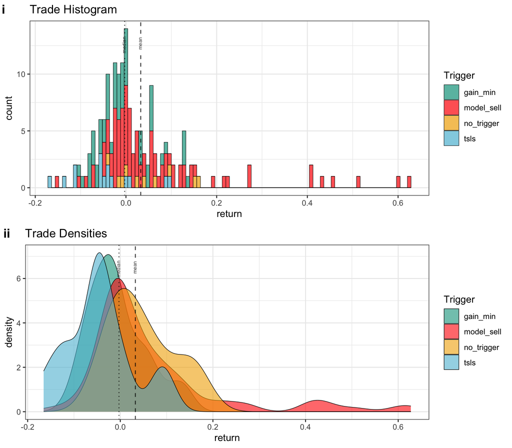

The following table summarizes trade statistics grouped by the selling trigger.

| Trigger | avg_return | avg_days | med_return | med_days | n_trades | trade_prop | avg_annual_factor | med_annual_factor |
| --- | --- | --- | --- | --- | --- | --- | --- | --- |
| gain_min | -0.005997704 | 28.38462 days | -0.01415776 | 28.5 days | 52 | 0.31325301 | 0.9255592 | 0.8330893 |
| model_sell | 0.066462088 | 17.67416 days | 0.01221080 | 9.0 days | 89 | 0.53614458 | 3.7767501 | 1.6359383 |
| no_trigger | 0.046601415 | 19.20000 days | 0.03106201 | 16.5 days | 10 | 0.06024096 | 2.3771199 | 1.9673226 |
| tsls | -0.044393146 | 23.06667 days | -0.05138369 | 21.0 days | 15 | 0.09036145 | 0.4874666 | 0.3997722 |

### b) Trade Results Over Time

The plot below shows the percentages of trade outcomes by quarter and year

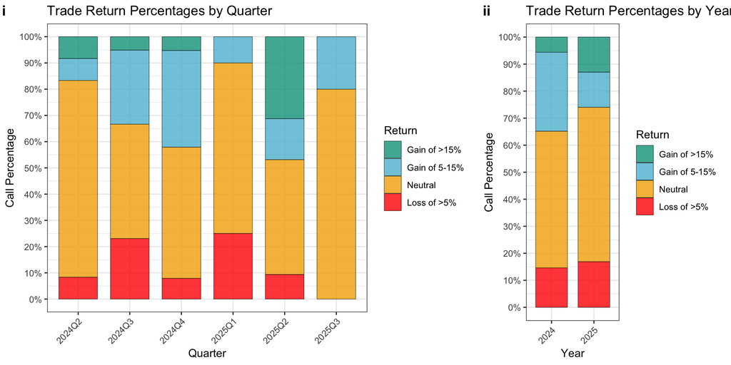

This figure displays the average return per trade and an estimated APY over time.

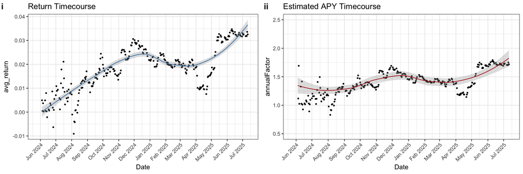

Histogram illustrating the change in the number of assets in the portfolio over time.

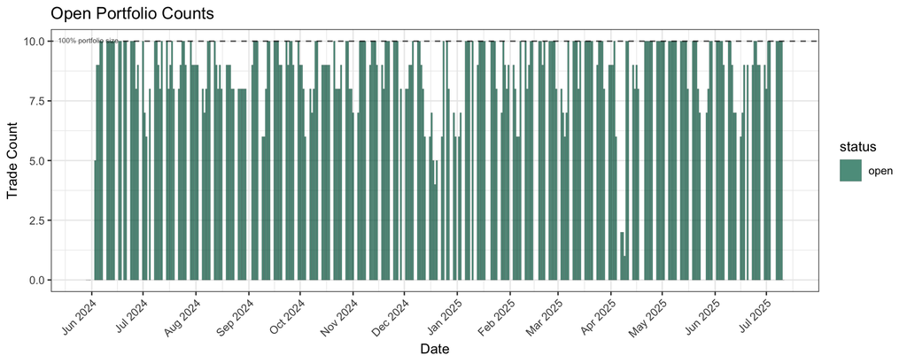

The table below contains a monthly summary of all trades and their performance.

| month | avg_return | med_return | med_days | n_trades | med_annual_factor |
| --- | --- | --- | --- | --- | --- |
| 2024-06 | 0.014116876 | -0.005429233 | 29.0 days | 12 | 1.1929575 |
| 2024-07 | -0.010530670 | -0.019297020 | 7.0 days | 20 | 0.5757908 |
| 2024-08 | 0.047334337 | 0.074922338 | 25.0 days | 9 | 1.9644727 |
| 2024-09 | 0.038895480 | 0.003304172 | 19.0 days | 10 | 2.0813930 |
| 2024-10 | 0.039134579 | 0.012210797 | 18.0 days | 15 | 2.1780457 |
| 2024-11 | 0.054215844 | 0.043374012 | 31.0 days | 11 | 1.8619878 |
| 2024-12 | 0.019195596 | 0.030429342 | 7.5 days | 12 | 2.5227073 |
| 2025-01 | -0.006265218 | -0.017801639 | 14.0 days | 15 | 0.8488634 |
| 2025-02 | -0.008503286 | -0.010737543 | 20.0 days | 10 | 0.8556888 |
| 2025-03 | -0.046696213 | -0.055005456 | 13.0 days | 15 | 0.2611436 |

[output cut: 4 more lines]